# The Social Media Radio Innovation and Its Impact on University Students' Ratings

An Exploratory Study

Sherif Rashwan

M.A. Defense Presentation | Media Innovations, Faculty of Mass Communication, Ahram Canadian University

Supervised by Dr. Engi Aboul-Ezz (Beni Suef University) and Dr. Mostafa El Banna (Ahram Canadian University)

November 2026

LOKLOK | Master's Defense | November 20261 / 36

Overview

## How this defense is organized

- Introduction: background, problem, importance, aim, objectives, questions, hypotheses
- Theory and platform: Epistemic Systems Theory and the LOKLOK design
- Methodology: three evidence layers, participants, instruments
- Results: headline contrast, decomposition, sensitivity, the trade-off, figures
- Robustness: randomized-assignment triangulation, controls, Gemini pilot
- Qualitative validation: an honest null result
- Answers, limitations, contribution, and future work

LOKLOK | Master's Defense | November 20262 / 36

Introduction

## From internet radio to social media radio

- Internet radio added live audio, scheduling, and global reach to broadcasting
- Social platforms added algorithmic recommendation, audience metrics, and social circulation
- Social media radio = programmed live voice + platform logic + public-service expectations
- Egyptian context: university radio traditions, digital media literacy gaps, misinformation pressure

LOKLOK | Master's Defense | November 20263 / 36

Introduction

## Why a radio-specific case, not generic social media

- Radio-like audio is voice-centered and temporally organized: a programmed stream, not an undifferentiated feed
- Broadcaster identity, vocal presence, sequence, and repair are directly observable
- Engagement has a behavioral referent: continued listening, replay, interaction
- Editorial, platform, and listener selection can be separated and varied as distinct levers
- Analytical generalization: the mechanism, not the medium, is the inferential target

LOKLOK | Master's Defense | November 20264 / 36

Introduction

## Statement of the problem

- Platform design, audience measurement, and epistemic quality live in separate literatures
- Filter bubbles, misinformation diffusion, and engagement pressure are studied without a measurable audience rating
- No existing framework links platform architecture to how students judge what they hear
- **Question:** can a social media radio design improve epistemic judgment **without losing the audience**?

LOKLOK | Master's Defense | November 20265 / 36

Introduction

## Importance of the study

- Joins platform design, audience measurement, and epistemic quality in one falsifiable framework (EST)
- Makes the core trade-off measurable: epistemic gain vs engagement cost
- Speaks to the Egyptian university media context with a public-service language for social audio
- Delivers a specified, testable design (LOKLOK) plus a plan for a real deployment
- Every claim is tiered and model-conditional: honesty as scientific practice

LOKLOK | Master's Defense | November 20266 / 36

Introduction

## Aim of the study

- To propose **Epistemic Systems Theory** and the **LOKLOK platform**, and to test, with a calibrated in-silico experiment anchored in a measured student wave, whether the epistemic-first design raises evaluative and competence-format ratings **without destroying engagement**
- The measured wave anchors the model; the simulation tests what the specified design implies
- No live trial was possible; no field causal effect is claimed

LOKLOK | Master's Defense | November 20267 / 36

Introduction

## Objectives

- Synthesize the literature into EST with four testable propositions
- Specify the LOKLOK architecture (BRS, MORE, ERIC, cooling, attention gate, measurement surface)
- Collect and analyze a measured wave of university students to anchor the model
- Build a reproducible calibrated in-silico experiment (500 personas, 8 cells, 18 sessions)
- Validate the qualitative codebook and apply the pre-set machine-coding gate
- Triangulate the contrast across four assignment designs
- Derive design implications and a plan for a real deployment

LOKLOK | Master's Defense | November 20268 / 36

Introduction

## Research questions

- **RQ1** Does platform architecture shape structural credibility and audience evaluation? (EST-P1)
- **RQ2** Do diversity and cooling mechanisms constrain epistemic concentration? (EST-P2)
- **RQ3** Can the proposed instruments meet basic psychometric accountability? (EST-P3)
- **RQ4** Do the EST constructs integrate into a coherent measurement model? (EST-P4)
- **RQ5** Which mechanisms and weights drive the model-based contrast?
- **RQ6** What does a Gemini persona-agent pilot add to the comparison?

LOKLOK | Master's Defense | November 20269 / 36

Introduction

## Hypotheses

- **H1** Structural credibility: architecture shapes credibility and evaluation (EST-P1)
- **H2** Diversity mechanism: diversity and cooling constrain epistemic concentration (EST-P2)
- **H3** Psychometric validity: instruments meet psychometric accountability (EST-P3)
- **H4** Integration: EST constructs form a coherent measurement model (EST-P4)
- **H5** DeGroot conformity (exploratory); **H6** scheduling and duration (exploratory)
- **H7** Participatory performance: the educational test (prospective)

LOKLOK | Master's Defense | November 202610 / 36

Framework

## Epistemic Systems Theory (EST)

- **EST-P1** Architecture is a structural condition of credibility
- **EST-P2** Diversity and cooling constrain epistemic concentration
- **EST-P3** Measurement is an accountability requirement
- **EST-P4** Participation and evidence-based production are the educational test
- A falsifiable language for linking design choices to audience judgment, not a universal law

LOKLOK | Master's Defense | November 202611 / 36

Platform

## LOKLOK: six design components

- **BRS** Broadcaster Reputation Score
- **MORE** Recommendations constrained to keep viewpoints varied
- **ERIC** Moderation loop: reflect, invite, correct
- **Echo Meter** and **Algorithmic Cooling**
- **Zewail-inspired attention gate** (time-resolved attentional coherence)
- Built-in **measurement surface**: evaluative and competence-format student ratings

LOKLOK | Master's Defense | November 202612 / 36

Methodology

## Three evidence layers, one honest hierarchy

- **Measured** 52 of 60 questionnaires, Uber riders in 6th of October City: anchors, not a causal test
- **Qualitative** FGD and self-report, 193 segments, 3 human coders: an assumption audit
- **Modeling** A calibrated in-silico experiment: what the specified design implies
- Mixed-methods integration through claim tiers: field, model, theory, prospective

LOKLOK | Master's Defense | November 202613 / 36

Methodology

## Participants and instruments

- **Participants:** 60 questionnaires collected; 8 duplicate vectors removed; N = 52 university students using Uber in 6th of October City, Giza
- **BRS:** 11-item broadcaster-rating battery (alpha .957)
- **PB:** 5-item perceived-benefit battery (alpha .947, omega .962)
- Star rating, ride duration, interaction level, and context items
- **NMLS:** published 35-item media-literacy profile scored with GRM-IRT; 8-item MCS+PB battery
- Convenience sample: descriptive anchoring, not population inference

LOKLOK | Master's Defense | November 202614 / 36

Methodology

## The measured wave in one slide

- Perceived benefit: M = 5.12, SD = 0.87 on a 7-point scale
- PB correlates with the star rating: rho = .67
- Reliability is high (alpha .957 and .947); the single-factor CFA fits poorly
- Therefore: reliability is reported, structural validity is **not** claimed
- The wave anchors the model level (G0 = 5.119) and the persona spread

LOKLOK | Master's Defense | November 202615 / 36

Methodology

## Qualitative corpus and coding design

- FGD 160 segments; self-report 185 segments; 60 participant-observation accounts; 4,828 corpus documents
- 25-code codebook: 12 deductive mechanism codes (C01-C12), 13 inductive codes (I01-I13)
- Three independent human coders on 193 usable segments
- Machine comparators: local Qwen 7B (zero-shot and gold 5-fold) and a Claude first pass
- Pre-set usability gate: 8 positives, kappa at least .60, at most 5% fabrication

LOKLOK | Master's Defense | November 202616 / 36

Qualitative validation

## An honest null result

- Human agreement: pooled pairwise kappa .762, .852, .861; per-code median .28 (C02) to .95 (I07)
- Leave-one-out human micro-F1 about .99 (97% of code cells are negative)
- Qwen 7B: micro-F1 .193 zero-shot, .320 with gold exemplars; Claude first pass .452
- **No mechanism code met the gate** in either local pass
- The qualitative layer remains an **assumption audit**; E1 and E2 exploratory, E3 not run

LOKLOK | Master's Defense | November 202617 / 36

Method

## The calibrated in-silico experiment

- **500 synthetic personas** drawn from the debiased distribution of the 52 respondents (DML + IPW, spectral manifold)
- **8 cells** (2³ A/B/C combinations), **18 sessions**, eight mathematical filters
- **GRM-IRT measurement**: 35-item NMLS competence profile, 8-item MCS+PB battery
- G0 arm anchored to the measured PB mean (5.119)
- State-outcome weights are **declared design assumptions**, not estimates

LOKLOK | Master's Defense | November 202618 / 36

Results

## Headline contrast (500 personas, 18 sessions)

| Outcome | Estimate | 95% interval | Test |
| --- | --- | --- | --- |
| Delta SR eval (1-7) | +0.827 | [0.779, 0.875] | t(499) = 33.93, d = 1.52 |
| Delta SR comp (0-100) | +11.30 | [10.64, 11.95] | t(499) = 33.74, d = 1.51 |
| Delta engagement (0-1) | -0.183 | [-0.188, -0.178] | t(499) = -74.41, d = -3.33 |

Intervals describe variation across generated personas, not human sampling precision.

LOKLOK | Master's Defense | November 202619 / 36

Results

## The evaluative shift inside the model

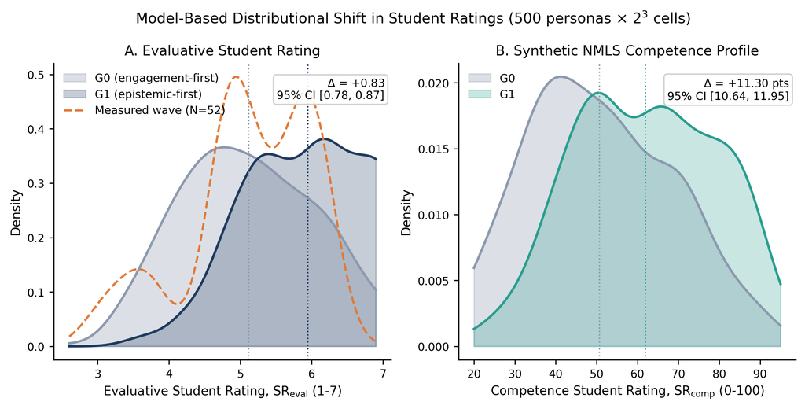

SR_eval distributions for G0, G1, and the measured wave (left); competence profile (right). The measured wave is an anchor, not a treatment arm.

LOKLOK | Master's Defense | November 202620 / 36

Decomposition

## Eight cells, one dominant path

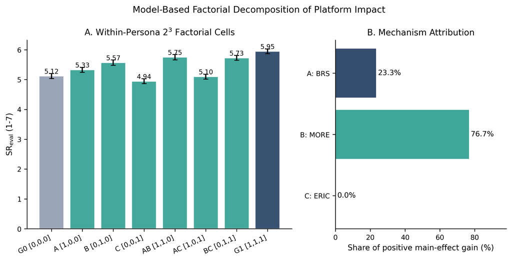

Eight cell means: B and BC stand out, A adds a smaller margin. B main +0.6265; B x C interaction +0.3791.

LOKLOK | Master's Defense | November 202621 / 36

Sensitivity

## The declared assumptions that matter

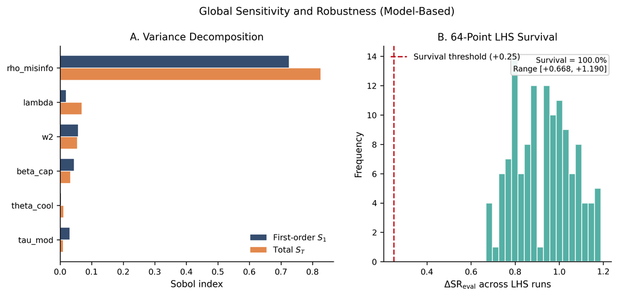

LOKLOK | Master's Defense | November 202622 / 36

Measurement

## GRM-IRT diagnostics

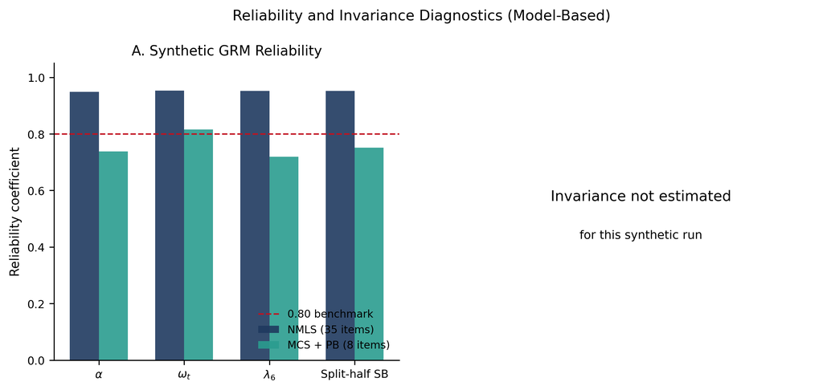

GRM-IRT scoring reproduces high internal consistency (NMLS alpha .948). This is the generating model, not human validation.

LOKLOK | Master's Defense | November 202623 / 36

Decomposition

## What drives the contrast

- **B (diversity and cooling)** carries most of it: main effect +0.6265
- A (BRS) adds +0.1905; C (ERIC) is near zero alone (-0.0121)
- **B x C interaction +0.3791**: nearly half of the total contrast
- 256-point joint sweep: **96.5% positive**, median +0.567, range -0.244 to +1.810
- Top driver: the declared diversity-to-credibility weight (PRCC +0.77)

LOKLOK | Master's Defense | November 202624 / 36

Trade-off

## The epistemic gain is not free

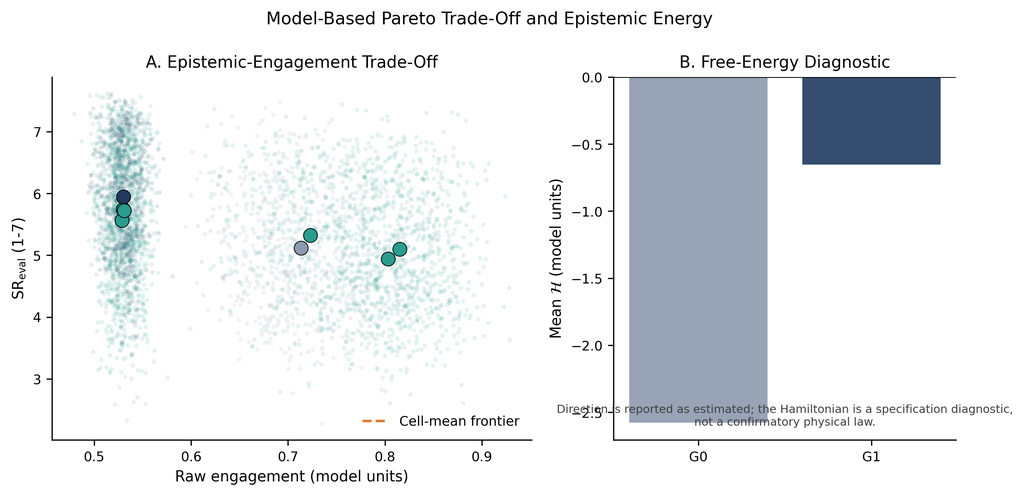

Pareto panel: no cell dominates G1 on both epistemic rating and engagement. The Hamiltonian is a specification diagnostic, not a physical law.

LOKLOK | Master's Defense | November 202625 / 36

Robustness

## Randomized-assignment triangulation

| Design | Worlds | Delta SR eval | Delta engagement |
| --- | --- | --- | --- |
| Within-persona | 1 | +0.827 | -0.217 |
| Agent-randomized | 40 | +0.630 [0.384, 0.851] | -0.232 |
| Design-based (no interference) | 400 | +0.807 [0.470, 1.109] | -0.217 |
| Cluster-randomized | 20 | +0.659 [0.338, 0.948] | -0.226 |

B stays near +0.63 in every design; A collapses from +0.190 to +0.038 between agents, then recovers to +0.182 without interference. B x C stays positive (+0.379 to +0.430 in effect terms).

LOKLOK | Master's Defense | November 202626 / 36

Robustness

## Controls, stress tests, and topologies

- Placebo factor D (absent from the equations): -0.003 SR eval, -0.082 SR comp
- Pre-treatment negative controls: +0.001, -0.008, 0.000 across the A/B/C margins
- Mechanism checks: B raises chosen diversity +1.299; A raises BRS +0.019; B x C lowers echo -0.340
- Adversarial content stress (poor-content share 0.763): contrast +0.636, still positive
- 60-row sensitivity +0.808; 50 anchor bootstraps +0.839 (100% positive); ER/WS/BA topologies +0.827/+0.826/+0.832

LOKLOK | Master's Defense | November 202627 / 36

Triangulation

## Gemini persona-agent pilot

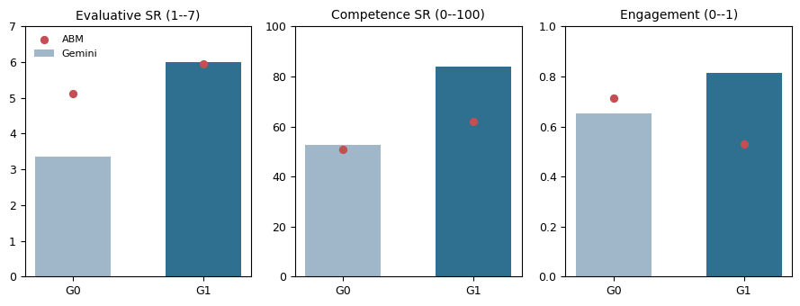

Gemini reproduces the direction but overstates the magnitude (+2.650) and reverses engagement (+0.163). Single-shot appraisal, not an 18-session simulation.

LOKLOK | Master's Defense | November 202628 / 36

Answers

## Answering the research questions

- **RQ1** architecture: partial support; measured associations plus the model BRS path; model-conditional
- **RQ2** diversity and cooling: supported within the model; the topology check is network-independent
- **RQ3** psychometrics: mixed; reliability high, structural validity not established
- **RQ4** integration: not established; the constructs remain framework-level
- **RQ5** drivers: cred_dbi +0.77, cred_brs +0.31, cred_echo -0.27; B main +0.6265
- **RQ6** Gemini: direction only; magnitude and engagement sign are not reproduced

LOKLOK | Master's Defense | November 202629 / 36

Answers

## Hypothesis results

- **H1** structural credibility: partial (model-conditional)
- **H2** diversity mechanism: supported within the model
- **H3** psychometric validity: mixed
- **H4** integration: not established
- **H5** conformity and **H6** scheduling: exploratory; no confirmatory claim
- **H7** participatory performance: prospective; untested

LOKLOK | Master's Defense | November 202630 / 36

Answers

## EST proposition verdicts

| Proposition | Hypotheses | Evidence | Verdict |
| --- | --- | --- | --- |
| EST-P1 architecture and credibility | H1, H4, H5 | Measured PB-star and BRS associations; model BRS path | Partial; model-conditional |
| EST-P2 diversity and cooling | H2 | MORE/Lagrange dominant; topology-independent | Supported within the model |
| EST-P3 measurement | H3 | High consistency; poor CFA; no invariance test | Mixed |
| EST-P4 participation | H7 | Prospective task; no human task data | Untested; future work |

Model-conditional statements are not human treatment effects.

LOKLOK | Master's Defense | November 202631 / 36

Boundaries

## What is deliberately not claimed

- No randomized field deployment; convenience sample; **no causal claim**
- Model weights are declared assumptions; the Bayesian check is a re-expression, not independent evidence
- No human NMLS validation; measurement invariance not estimated
- BRS is not validated as a consequential ranking instrument
- The engagement metric differs by convention: -0.183 session-average, -0.217 terminal; both reported

LOKLOK | Master's Defense | November 202632 / 36

Contribution

## What this thesis contributes

- **EST**: a falsifiable framework linking architecture, audience judgment, and measurement
- **LOKLOK**: a specified, testable platform design
- A reproducible calibrated in-silico experiment plus a plan for a real deployment
- A transparent reporting standard: assumption audit, claim tiers, and a pre-set machine-coding gate

LOKLOK | Master's Defense | November 202633 / 36

Future work

## From model to field

- Prospective platform experiment with frozen allocations and disclosed LLM-agent logs
- Longitudinal human NMLS validation and measurement invariance
- E3: respondent-level theme features vs BGE-PCA (requires the provenance pass)
- Optional model polish: per-code machine calls, threshold tuning, and a pre-set stop rule
- The next test is a real LOKLOK deployment, not another simulation

LOKLOK | Master's Defense | November 202634 / 36

Defense readiness

## Three numbers, four expected questions

- Three numbers to remember: **+0.827**, **-0.183**, **96.5%**
- Is this just MORE? Yes: diversity-seeking selection plus a declared credibility weight is the design claim
- Shuffled text gives the same answer? The data set the level and persona spread, not the contrast
- Why does the default sit at the 78th percentile of the sweep? Declared design values; the sweep brackets them
- Why is the baseline gate open only about 15% of the time? A strong attentional filter; the dephasing time is an assumption

LOKLOK | Master's Defense | November 202635 / 36

# Thank you

Questions and discussion welcome

The Social Media Radio Innovation and Its Impact on University Students' Ratings

LOKLOK | Master's Defense | November 202636 / 36